# Survey Data, Censuses, and Age Standardization in Health Sciences

Author

Sudipto Banerjee  
Department of Biostatistics  
Department of Statistics & Data Science  
Institute of the Environment & Sustainability  
UCLA

# 1 Introduction: Survey Data in Public Health and Data Science

Modern public health research, epidemiological surveillance, and health policy depend heavily on probability sampling and survey design. Whether investigating disease prevalence, tracking environmental exposures, or evaluating healthcare utilization, collecting data from every individual in a target population is rarely feasible.

In this introductory lecture, we explore the foundational role of **censuses** and **sample surveys** in health statistics. We examine landmark health surveys, learn how censuses provide vital population denominators, and investigate **age-standardization**—a critical epidemiological method that serves as our conceptual gateway to **stratified sampling**.

# 2 Censuses vs. Sample Surveys in Health Research

Population data collection broadly falls into two paradigms: complete enumerations (**censuses**) and probabilistic subset selections (**sample surveys**).

Key Concepts: Censuses and Sample Surveys

- **Census (Complete Enumeration):** An attempt to collect data from *every* unit in a well-defined finite target population $U = \{1, 2, \dots, N\}$.
- **Sample Survey:** A systematic process of selecting a subset $S \subset U$ of size $n < N$ according to a pre-specified probabilistic sampling design $P(S)$.

## 2.1 Major US Health Surveys and Data Systems

Health data scientists routinely analyze large-scale national surveys. Four primary systems illustrate different sampling methodologies and objectives:

1. **National Health and Nutrition Examination Survey (NHANES):**
   - *Structure:* Continuous multi-stage probability sample of the non-institutionalized US civilian population.
   - *Unique Feature:* Combines household interviews with standardized physical examinations and laboratory tests in Mobile Examination Centers (MECs).
2. **Behavioral Risk Factor Surveillance System (BRFSS):**
   - *Structure:* World’s largest continuously conducted health survey, administered by state health departments with CDC support.
   - *Unique Feature:* Random-digit-dialed (RDD) landline and cellular telephone survey measuring behavioral risk factors (e.g., smoking, physical activity, alcohol consumption).
3. **National Health Interview Survey (NHIS):**
   - *Structure:* Cross-sectional household interview survey using complex multi-stage cluster sampling.
   - *Unique Feature:* Primary source of national data on healthcare access, chronic conditions, and disability.
4. **US Decennial Census & American Community Survey (ACS):**
   - *Structure:* The Decennial Census provides complete population counts ($N$), while the ACS provides continuous rolling sample estimates of demographic and socio-economic characteristics.
   - *Unique Feature:* Supplies the **population denominators** ($P$) required to calculate disease rates, incidence, and mortality across demographic subgroups and geographic boundaries.

# 3 Population Denominators and Crude Rates

In epidemiology and vital statistics, measuring disease occurrence requires placing health events (numerators) in context with the population at risk (denominators).

**Definition: Crude Mortality Rate (CMR)**  
Let $D$ denote the total number of deaths recorded in a region during a given time period, and let $P$ denote the total person-time at risk (or mid-year total population size). The Crude Mortality Rate is defined as:

$$\text{CMR} = \frac{D}{P}$$

Commonly expressed per $1,000$ or $100,000$ person-years.

## 3.1 The Danger of Crude Rate Comparisons: Simpson’s Paradox

Directly comparing crude mortality rates across different populations (e.g., two counties, states, or countries) can lead to profoundly misleading conclusions when the populations differ in underlying demographic structures—most notably, **age distribution**.

Because overall mortality risk increases dramatically with age, a population with a large proportion of elderly residents (e.g., Florida) will naturally exhibit a higher crude mortality rate than a population with a younger demographic profile (e.g., Utah), even if the younger population actually experiences higher mortality rates within *every single age bracket*.

This phenomenon is a classical manifestation of **confounding by age** (or **Simpson’s Paradox**). To make meaningful comparisons, we must adjust for age differences using **age standardization**.

## 3.2 A Concrete Numerical Illustration of Simpson’s Paradox

To see Simpson’s Paradox in action, consider two communities with equal total populations of $N = 100,000$:

- **County A:** An older retiree community where $80\%$ of the population is $\ge 65$.
- **County B:** A younger college town where $80\%$ of the population is $< 65$.

Suppose County B experiences **higher mortality rates than County A in every single age bracket**:

- Among young residents ($<65$): County B’s rate is $1.5$ per $1,000$ vs. County A’s $1.0$ per $1,000$.
- Among older residents ($\ge 65$): County B’s rate is $25.0$ per $1,000$ vs. County A’s $20.0$ per $1,000$.

### 3.2.1 Data Table and Numerical Setup

```r
library(knitr)

# Construct 2-Stratum Simpson's Paradox Dataset
simpson_df <- data.frame(
  Age_Group = c("Young (<65)", "Old (>=65)"),
  Pop_A = c(20000, 80000),      # County A: 80% Old
  Deaths_A = c(20, 1600),       # Rates: 1.0 per 1k (Young), 20.0 per 1k (Old)
  Pop_B = c(80000, 20000),      # County B: 80% Young
  Deaths_B = c(120, 500)        # Rates: 1.5 per 1k (Young), 25.0 per 1k (Old)
)

# Compute Within-Stratum Age-Specific Rates per 1,000
simpson_df$Rate_A <- (simpson_df$Deaths_A / simpson_df$Pop_A) * 1000
simpson_df$Rate_B <- (simpson_df$Deaths_B / simpson_df$Pop_B) * 1000

# Display Data Table
kable(simpson_df, digits = 2,
      caption = "Table 1: Two-Stratum Demonstration of Simpson's Paradox")
```

Table 1: Two-Stratum Demonstration of Simpson’s Paradox

| Age_Group | Pop_A | Deaths_A | Pop_B | Deaths_B | Rate_A | Rate_B |
| --- | --- | --- | --- | --- | --- | --- |
| Young (<65) | 20000 | 20 | 80000 | 120 | 1 | 1.5 |
| Old (>=65) | 80000 | 1600 | 20000 | 500 | 20 | 25.0 |

### 3.2.2 Hand Calculations: Stratum Rates vs. Overall Crude Rates

To see how the numbers in Table 1 aggregate into overall rates:

1. **Age-Specific Stratum Rates ($r_h = \frac{D_h}{P_h} \times 1,000$):**
   - **Young ($<65$):**
     - County A: $\frac{20}{20,000} \times 1,000 = 1.00\text{ per } 1,000$
     - County B: $\frac{120}{80,000} \times 1,000 = 1.50\text{ per } 1,000$ *(Higher mortality in B)*
   - **Old ($\ge 65$):**
     - County A: $\frac{1,600}{80,000} \times 1,000 = 20.00\text{ per } 1,000$
     - County B: $\frac{500}{20,000} \times 1,000 = 25.00\text{ per } 1,000$ *(Higher mortality in B)*
2. **Overall Crude Mortality Rates ($\text{CMR} = \sum v_h r_h$):**
   - **County A (80% Elderly Population Weight):**
     $$\text{CMR}_A = (0.20 \times 1.00) + (0.80 \times 20.00) = 0.20 + 16.00 = 16.20\text{ per } 1,000$$
   - **County B (80% Young Population Weight):**
     $$\text{CMR}_B = (0.80 \times 1.50) + (0.20 \times 25.00) = 1.20 + 5.00 = 6.20\text{ per } 1,000$$

Even though County B experiences higher mortality rates in **every age bracket** ($1.50 > 1.00$ and $25.00 > 20.00$), County A’s unadjusted crude rate is **nearly 2.6 times higher** ($16.20$ vs. $6.20$) simply because $80\%$ of its population sits in the high-risk elderly stratum.

### 3.2.3 Graphical Illustration

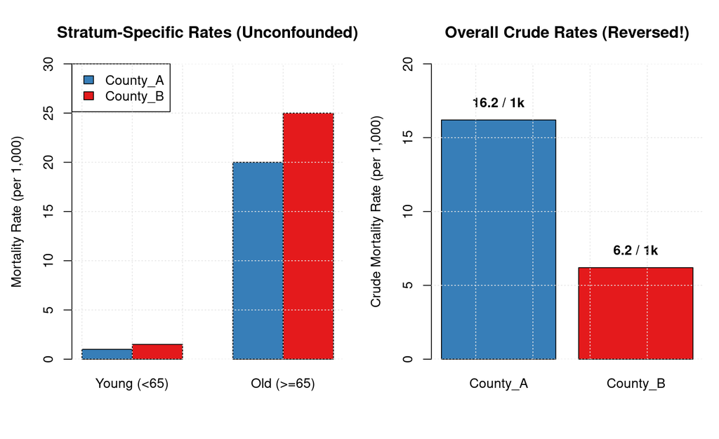

Figure 1: Illustration of Simpson’s Paradox. Left: Within every age stratum, County B has higher mortality rates. Right: Because County A is composed predominantly of older individuals, its unadjusted crude mortality rate is nearly 2.6 times higher than County B’s.

```r
# Compute Overall Crude Rates per 1,000
crude_A <- (sum(simpson_df$Deaths_A) / sum(simpson_df$Pop_A)) * 1000
crude_B <- (sum(simpson_df$Deaths_B) / sum(simpson_df$Pop_B)) * 1000

# Visualizing Simpson's Paradox in Base R
par(mfrow = c(1, 2), mar = c(5, 4.5, 4, 1))

# Panel 1: Age-Specific Rates
rate_matrix_strat <- rbind(County_A = simpson_df$Rate_A, County_B = simpson_df$Rate_B)
colnames(rate_matrix_strat) <- simpson_df$Age_Group

barplot(rate_matrix_strat, beside = TRUE, col = c("#377eb8", "#e41a1c"),
        ylab = "Mortality Rate (per 1,000)", main = "Stratum-Specific Rates (Unconfounded)",
        legend.text = TRUE, args.legend = list(x = "topleft", bg = "white"),
        ylim = c(0, 30))
grid(col = "gray90", lty = "dotted")

# Panel 2: Overall Crude Rates
crude_vec <- c(County_A = crude_A, County_B = crude_B)
bp <- barplot(crude_vec, col = c("#377eb8", "#e41a1c"),
              ylab = "Crude Mortality Rate (per 1,000)",
              main = "Overall Crude Rates (Reversed!)",
              ylim = c(0, 20))
text(x = bp, y = crude_vec + 1.2, labels = paste0(round(crude_vec, 2), " / 1k"), font = 2)
grid(col = "gray90", lty = "dotted")
```

```r
par(mfrow = c(1, 1))
```

**Why Does the Paradox Occur?**  
The crude mortality rate is a weighted average of stratum rates: $\text{CMR} = \sum v_h r_h$, where $v_h = P_h / P$ is the proportion of the population in age stratum $h$.

- County A places $80\%$ of its weight on the high-risk “Old” stratum ($r_{\text{old}} = 20.0$), pulling its crude rate up to $16.20$ per $1,000$.
- County B places $80\%$ of its weight on the low-risk “Young” stratum ($r_{\text{young}} = 1.5$), pulling its crude rate down to $6.20$ per $1,000$.

The unadjusted crude rate reflects the **demographic composition** of the population rather than its underlying healthcare quality or biological risk.

# 4 Mathematics of Age Standardization

Age standardization recalculates summary rates by holding age distribution constant. Suppose a population $U$ is partitioned into $H$ mutually exclusive age categories (strata) $h = 1, 2, \dots, H$.

For each age stratum $h$:

- $P_h$ = Population size in age stratum $h$ (with total population $P = \sum_{h=1}^H P_h$).
- $D_h$ = Number of deaths observed in age stratum $h$ (with total deaths $D = \sum_{h=1}^H D_h$).
- $r_h = \frac{D_h}{P_h}$ = **Age-specific mortality rate** in stratum $h$.

The Crude Mortality Rate can be rewritten as a **weighted average** of age-specific rates:

$$\text{CMR} = \frac{D}{P} = \frac{\sum_{h=1}^H D_h}{P} = \sum_{h=1}^H \left(\frac{P_h}{P}\right) \left(\frac{D_h}{P_h}\right) = \sum_{h=1}^H v_h r_h$$

where $v_h = \frac{P_h}{P}$ represents the internal population proportion (weight) of age stratum $h$.

## 4.1 Direct Age Standardization

Direct standardization applies the observed age-specific rates $r_h$ of a study population to an external **standard reference population** (e.g., the US 2000 Standard Population).

Formula: Direct Age-Standardized Mortality Rate (ASMR)

Let $P_h^{\text{std}}$ denote the population size of stratum $h$ in the standard reference population, and let $P^{\text{std}} = \sum_{h=1}^H P_h^{\text{std}}$.

The **Standard Population Weight** for stratum $h$ is:
$$w_h = \frac{P_h^{\text{std}}}{P^{\text{std}}} \quad \text{such that} \quad \sum_{h=1}^H w_h = 1$$

The **Direct Age-Standardized Mortality Rate (ASMR)** is:
$$\text{ASMR} = \sum_{h=1}^H w_h r_h = \sum_{h=1}^H w_h \left(\frac{D_h}{P_h}\right)$$

By applying identical weights $w_h$ to different study populations, differences in crude rates caused by age structure are completely eliminated.

**Conceptual Connection: Age Standardization as Stratified Weighted Estimation**

Looking Ahead to Stratified Random Sampling

Notice the exact mathematical form of the Direct Standardized Rate:

$$\text{ASMR} = \sum_{h=1}^H w_h r_h$$

This expression is formally identical to a **stratified domain estimator**:

1. The population is partitioned into $H$ distinct **strata** defined by age groups.
2. Within each stratum $h$, an age-specific rate $r_h$ is computed.
3. The overall summary statistic is constructed as a **linear combination of stratum-specific estimates** weighted by standardized stratum proportions $w_h$.

Later in this course, when we formalize **Stratified Random Sampling**, **post-stratification**, and **Horvitz-Thompson estimation**, you will recognize that age-standardization is simply an early epidemiological instance of stratified weight adjustment!

## 4.2 Indirect Age Standardization and the Standardized Mortality Ratio (SMR)

When stratum-specific death counts $D_h$ in a small study population are unstable or unavailable, but total deaths $D_{\text{obs}}$ and age-specific population counts $P_h$ are known, **indirect standardization** is used.

Indirect standardization applies reference age-specific mortality rates $r_h^{\text{std}}$ from a large baseline population (e.g., national rates) to the age structure of the local study population.

Formula: Standardized Mortality Ratio (SMR)

1. **Expected Deaths ($E$):** The number of deaths expected in the study population if it experienced the reference rates $r_h^{\text{std}}$:
   $$E = \sum_{h=1}^H P_h r_h^{\text{std}}$$
2. **Standardized Mortality Ratio (SMR):**
   $$\text{SMR} = \frac{D_{\text{obs}}}{E} = \frac{\sum_{h=1}^H D_h}{\sum_{h=1}^H P_h r_h^{\text{std}}}$$
3. **Indirect Age-Standardized Mortality Rate:**
   $$\text{Indirect ASMR} = \text{SMR} \times \text{CMR}_{\text{std}}$$
- Interpretation: An $\text{SMR} > 1.0$ indicates that the study population experienced *more* deaths than expected given its age structure, while an $\text{SMR} < 1.0$ indicates *fewer* deaths than expected.

# 5 Practical R Implementation and Numerical Example

We now implement a multi-stratum numerical example in R comparing two counties across four age brackets.

## 5.1 Scenario Setup

Consider two health jurisdictions with distinct demographic structures evaluated against the US 2000 Standard Population:

- **County A (Sun City):** Coastal community with a large retiree population.
- **County B (Metro Young):** Urban tech hub with a young demographic profile.

```r
# Load required libraries
library(knitr)

# Define Age Strata
age_groups <- c("0-17", "18-44", "45-64", "65+")

# Define Population Counts (Denominators from Census data)
pop_County_A <- c(15000, 25000, 30000, 30000)  # Total = 100,000 (30% 65+)
pop_County_B <- c(30000, 45000, 18000, 7000)   # Total = 100,000 (7% 65+)

# Observed Deaths (Numerators from Vital Statistics)
deaths_County_A <- c(12, 50, 210, 1200)       # Total deaths = 1,472
deaths_County_B <- c(30, 112, 162, 315)        # Total deaths = 619

# Standard Reference Population (US 2000 Standard Population proportions)
pop_Standard <- c(260000, 380000, 220000, 140000) # Total = 1,000,000

# Construct Primary Dataset
df <- data.frame(
  Age_Group = age_groups,
  Pop_A = pop_County_A,
  Deaths_A = deaths_County_A,
  Pop_B = pop_County_B,
  Deaths_B = deaths_County_B,
  Pop_Std = pop_Standard
)

# 1. Compute Age-Specific Rates per 1,000 person-years
df$Rate_A_per1k <- (df$Deaths_A / df$Pop_A) * 1000
df$Rate_B_per1k <- (df$Deaths_B / df$Pop_B) * 1000

# 2. Compute Standard Population Weights (w_h)
w_std <- df$Pop_Std / sum(df$Pop_Std)
df$Std_Weight <- w_std

# Display Structured Summary Table
kable(df, digits = 4, caption = "Table 2: Age-Specific Population Counts, Deaths, and Rates for Counties A and B")
```

Table 2: Age-Specific Population Counts, Deaths, and Rates for Counties A and B

| Age_Group | Pop_A | Deaths_A | Pop_B | Deaths_B | Pop_Std | Rate_A_per1k | Rate_B_per1k | Std_Weight |
| --- | --- | --- | --- | --- | --- | --- | --- | --- |
| 0-17 | 15000 | 12 | 30000 | 30 | 260000 | 0.8 | 1.0000 | 0.26 |
| 18-44 | 25000 | 50 | 45000 | 112 | 380000 | 2.0 | 2.4889 | 0.38 |
| 45-64 | 30000 | 210 | 18000 | 162 | 220000 | 7.0 | 9.0000 | 0.22 |
| 65+ | 30000 | 1200 | 7000 | 315 | 140000 | 40.0 | 45.0000 | 0.14 |

## 5.2 Computing Crude and Direct Age-Standardized Rates

We now calculate the Crude Mortality Rates and Direct Age-Standardized Mortality Rates for both counties:

```r
# Total Populations and Total Deaths
total_pop_A <- sum(df$Pop_A)
total_pop_B <- sum(df$Pop_B)

total_deaths_A <- sum(df$Deaths_A)
total_deaths_B <- sum(df$Deaths_B)

# Crude Mortality Rates per 1,000
cmr_A <- (total_deaths_A / total_pop_A) * 1000
cmr_B <- (total_deaths_B / total_pop_B) * 1000

# Direct Age-Standardized Mortality Rates (ASMR) per 1,000
asmr_A <- sum(df$Std_Weight * df$Rate_A_per1k)
asmr_B <- sum(df$Std_Weight * df$Rate_B_per1k)

# Format Results Table
summary_results <- data.frame(
  Metric = c("Total Population", "Total Deaths", "Crude Mortality Rate (per 1,000)", "Direct Standardized Rate (per 1,000)"),
  County_A = c(format(total_pop_A, big.mark=","), total_deaths_A, round(cmr_A, 3), round(asmr_A, 3)),
  County_B = c(format(total_pop_B, big.mark=","), total_deaths_B, round(cmr_B, 3), round(asmr_B, 3))
)

kable(summary_results, caption = "Table 3: Crude vs. Direct Age-Standardized Mortality Rates")
```

Table 3: Crude vs. Direct Age-Standardized Mortality Rates

| Metric | County_A | County_B |
| --- | --- | --- |
| Total Population | 1e+05 | 1e+05 |
| Total Deaths | 1472 | 619 |
| Crude Mortality Rate (per 1,000) | 14.72 | 6.19 |
| Direct Standardized Rate (per 1,000) | 8.108 | 9.486 |

## 5.3 Computing Indirect Standardization and SMR in R

Suppose County B’s age-specific death counts were unavailable, and we only knew its total observed deaths ($D_{\text{obs}} = 619$) and population age structure $P_h$. Using County A’s rates as the reference standard $r_h^{\text{std}}$:

```r
# Reference Rates (County A age-specific rates per person, not per 1k)
ref_rates_A <- df$Deaths_A / df$Pop_A

# Expected Deaths in County B under County A's reference rates
expected_deaths_B <- sum(df$Pop_B * ref_rates_A)

# Observed Deaths in County B
observed_deaths_B <- total_deaths_B

# Standardized Mortality Ratio (SMR)
smr_B <- observed_deaths_B / expected_deaths_B

cat("Indirect Standardization Results for County B (Reference = County A):\n")
```

```
Indirect Standardization Results for County B (Reference = County A):
```

```r
cat("------------------------------------------------------------------\n")
cat("Expected Deaths in County B (E):", round(expected_deaths_B, 2), "\n")
```

```
Expected Deaths in County B (E): 520
```

```r
cat("Observed Deaths in County B (D):", observed_deaths_B, "\n")
```

```
Observed Deaths in County B (D): 619
```

```r
cat("Standardized Mortality Ratio (SMR):", round(smr_B, 4), "\n")
```

```
Standardized Mortality Ratio (SMR): 1.1904
```

## 5.4 Visualizing Age Distributions and Rate Profiles

We visualize the demographic age distributions alongside the crude vs. standardized mortality rates for the four-strata example:

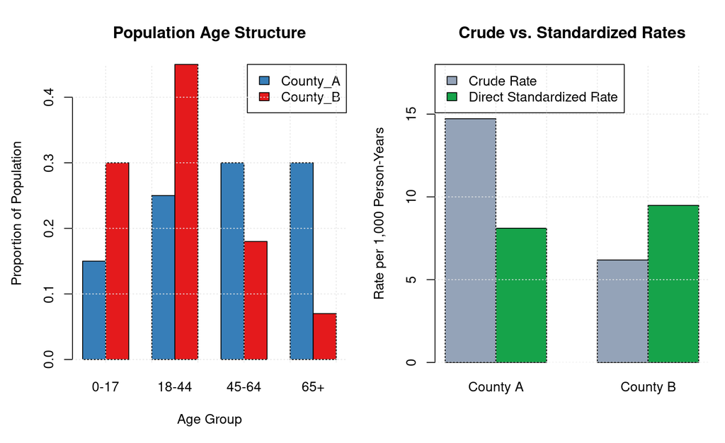

Figure 2: Demographic Age Distribution and Mortality Rate Adjustment across Four Age Strata.

```r
# Set up a 1x2 side-by-side plot layout
par(mfrow = c(1, 2), mar = c(5, 4.5, 4, 1))

# Plot 1: Age Distributions (Proportion of Population)
prop_A <- df$Pop_A / total_pop_A
prop_B <- df$Pop_B / total_pop_B

bp_data <- rbind(County_A = prop_A, County_B = prop_B)
barplot(bp_data, beside = TRUE, col = c("#377eb8", "#e41a1c"),
        names.arg = age_groups, xlab = "Age Group", ylab = "Proportion of Population",
        main = "Population Age Structure", legend.text = TRUE,
        args.legend = list(x = "topright", bg = "white"))
grid(col = "gray90", lty = "dotted")

# Plot 2: Crude vs. Standardized Mortality Rates
rate_matrix <- matrix(c(cmr_A, cmr_B, asmr_A, asmr_B), nrow = 2, byrow = TRUE)
colnames(rate_matrix) <- c("County A", "County B")
rownames(rate_matrix) <- c("Crude Rate", "Direct Standardized Rate")

barplot(rate_matrix, beside = TRUE, col = c("#94a3b8", "#16a34a"),
        ylab = "Rate per 1,000 Person-Years", main = "Crude vs. Standardized Rates",
        legend.text = TRUE, args.legend = list(x = "topleft", bg = "white"),
        ylim = c(0, 18))
grid(col = "gray90", lty = "dotted")
```

```r
# Reset layout
par(mfrow = c(1, 1))
```

# 6 Summary and Outlook

In this introductory lecture, we established:

1. **Role of Survey Systems:** The fundamental distinction between census enumerations ($N$) and sample survey designs ($n < N$), and their roles in generating numerators and denominators for health metrics.
2. **Simpson’s Paradox in Mortality Rates:** How unadjusted demographic compositions can invert overall rate comparisons when age acts as a confounder.
3. **Direct Age-Standardization:** Weighting age-specific rates $r_h$ by standard population weights $w_h$ to yield comparable summary rates:
   $$\text{ASMR} = \sum_{h=1}^H w_h r_h$$
4. **Indirect Standardization:** Computing expected deaths $E = \sum P_h r_h^{\text{std}}$ and the Standardized Mortality Ratio $\text{SMR} = D_{\text{obs}} / E$.
5. **Bridge to Survey Sampling:** Recognizing age-standardization as an early application of **stratified weight adjustment** across sub-populations.

Next, we will introduce ourselves to **Probability Sampling** in finite sample spaces, developing the mathematical foundations, applications to finite population survey sampling and computational implementations in R.